# Introdução ao Aprendizado de Máquina

## Esboço do minicurso

- Introdução (30 minutos)
- Resolvendo um problema de previsão (1 hora e meia)
- Intervalo (15 minutos)
- Problemas de classificação (45 minutos)
- Redução de dimensionalidade (15 minutos)
- Problemas de agrupamento(30 minutos)

## O que é Aprendizado de Máquina?

- Em 2002, [George Hinton](http://www.cs.toronto.edu/~hinton/) publicou um [artigo](https://ieeexplore.ieee.org/document/982899?arnumber=982899) demonstrando que um rede neuronal era capaz de reconhecer dígitos escritos a mão com a precisão de um humano (> 98%)

[figure not shown]

## O que é Aprendizado de Máquina?

- Desde então, as técnicas de apendizado de máquina conquistaram a Indústria
  - produtos de tecnologia em geral
  - buscas na web
  - reconhecimento de voz em smartphones
  - sistema de recomendação de videos
  - detectando transações fraudulentas em bancos

[figure not shown]

## O que é Aprendizado de Máquina?

- Aprendizado de máquina é a ciência (arte) de programar computadores de modo que eles possam aprender com os dados.

[figure not shown]

## Uma definição mais geral

- Aprendizado de Máquina é o campo de estudo de dá aos computadores a capacidade de aprenderem sem ser explicitamente programados

  ```
    Arthur Samuel, 1959
  ```

## E uma definição mais orientada para a engenharia:

- Diz-se que um programa de computador aprende com a experiência E em relação a alguma tarefa T e alguma medida de desempenho P, se seu desempenho em T, medido por P, melhora com a experiência E.

  ```
    Tom Mitchell, 1997
  ```

## Por que usar Aprendizado de Máquina?

- Você pode descobrir algumas jóias escondidas se você souber onde olhar
  - registros de usuários
  - dados financeiros
  - dados de produção
  - dados de sensores de máquinas
  - relatórios de RH

[figure not shown]

## Mas nem sempre tudo funciona bem

- O sucesso dos modelos de Aprendizado de Máquina depende
  - quantidade dos dados
  - qualidade dos dados
  - características não informativas
  - habilidades do programador
  - experiência do analista

[figure not shown]

## Referência Básica

- [Hands-On Machine Learning with Scikit-Learn and TensorFlow: Concepts, Tools, and Techniques to Build Intelligent Systems](http://shop.oreilly.com/product/0636920052289.do)
  - Aurélien Géron
  - O'Reilly Media

[figure not shown]

## Ferramentas Básicas

- [python](https://www.python.org/)

[figure not shown]

## Ferramentas Básicas

- [numpy](http://www.numpy.org/)

[figure not shown]

## Ferramentas Básicas

- [scikit-learn](http://scikit-learn.org/stable/)

[figure not shown]

## Ferramentas Básicas

- [pandas](https://pandas.pydata.org/)

[figure not shown]

## O que vamos aprender nesse minicurso?

[figure not shown]

## Tipos de Sistemas de Aprendizado de Máquina (não exclusivo)

- Se são treinados ou não com a supervisão humana
  - Supervisionado
  - Semi-supervisionado
  - Não-supervisionado
  - Aprendizado por reforço
- Se eles podem aprender incrementalmente ou não
  - Aprendizado online
  - Aprendizado batch
- Se eles trabalham comparando dados novos com antigos, ou detectam modelos para construir um modelo preditivo
  - Instance-based
  - Model-based

## Aprendizado Supervisionado

- Os dados incluem a solução desejada (rótulos ou valores numéricos)
- Tarefas
  1. Classificação
  2. Regressão

[figure not shown]

## Aprendizado Não-supervisionado

- Os dados não têm rótulos, o sistema aprende sem um *professor*
- Importância dos atributos das amostras
- Tarefas
  1. Agrupamento
  2. Visualização (redução de dimensionalidade)
  3. Detecção de anomalias

[figure not shown]

## Aprendizado Não-supervisionado

## Agrupamento

[figure not shown]

## Aprendizado Não-supervisionado

## Redução de dimensionalidade

[figure not shown]

## Aprendizado Não-supervisionado

## Detecção de anomalias

[figure not shown]

## Aprendizado Semi-supervisionado

- Algumas amostras são rotuladas, outras não são
- Tarefas
  1. Agrupamento
  2. Detecção de anomalias

## Aprendizado Semi-supervisionado

## Exemplo: Google Photos

[figure not shown]

## Aprendizado por Reforço

- O sistema é tratado com um **agente**
  - *observa* o ambiente
  - seleciona e realiza *ações*
  - recebe *recompensas* ou *penalidades*
- O agente aprende uma estratégia (**política** de atuação)

[figure not shown]

## Aprendizado por Reforço

[figure not shown]

## Aprendizado Batch/Online

[figure not shown]

## Aprendizado Model-based / Instance-based

[figure not shown]

# Checklist de um projeto de Aprendizado de Máquina

## Checklist

1. Entender o problema
2. Obter os dados
3. Explorar os dados para obter *insights*
4. Preparar os dados para os algoritmos de aprendizado de máquina
5. Explorar diferentes modelos
6. Ajustar os modelos e combiná-los se necessário
7. Apresentar sua solução
8. Monitorar e dar manutenção no sistema desenvolvido

# Dinheiro traz felicidade?

## Entendendo o problema

- Existe uma relação entre o nível de satisfação e o Produto Interno Bruto de um país? ]
- Dados de 2015
  - BLI: Better Life Index
  - GDP: Gross Domestic Product (GDP)

[figure not shown]

- Essas informações podem ser retradas das seguintes fontes
  - [OECD](https://stats.oecd.org/index.aspx?DataSetCode=BLI)
  - [FMI](http://goo.gl/j1MSKe)

## Carregando os dados do Índice de Satisfação

```python
# Antes de iniciar,garantir a compatibilidade com python 2 e python 3
from __future__ import division, print_function, unicode_literals

import pandas as pd

# endereço do arquivo *.csv
url = "https://raw.githubusercontent.com/ageron/handson-ml/master/datasets/lifesat/oecd_bli_2015.csv"
oecd_bli=pd.read_csv(url)

oecd_bli.columns
```

```
Index(['LOCATION', 'Country', 'INDICATOR', 'Indicator', 'MEASURE', 'Measure',
       'INEQUALITY', 'Inequality', 'Unit Code', 'Unit', 'PowerCode Code',
       'PowerCode', 'Reference Period Code', 'Reference Period', 'Value',
       'Flag Codes', 'Flags'],
      dtype='object')
```

```python
oecd_bli.head(4)
```

|  | LOCATION | Country | INDICATOR | Indicator | MEASURE | Measure | INEQUALITY | Inequality | Unit Code | Unit | PowerCode Code | PowerCode | Reference Period Code | Reference Period | Value | Flag Codes | Flags |
| --- | --- | --- | --- | --- | --- | --- | --- | --- | --- | --- | --- | --- | --- | --- | --- | --- | --- |
| 0 | AUS | Australia | HO_BASE | Dwellings without basic facilities | L | Value | TOT | Total | PC | Percentage | 0 | units | NaN | NaN | 1.1 | E | Estimated value |
| 1 | AUT | Austria | HO_BASE | Dwellings without basic facilities | L | Value | TOT | Total | PC | Percentage | 0 | units | NaN | NaN | 1.0 | NaN | NaN |
| 2 | BEL | Belgium | HO_BASE | Dwellings without basic facilities | L | Value | TOT | Total | PC | Percentage | 0 | units | NaN | NaN | 2.0 | NaN | NaN |
| 3 | CAN | Canada | HO_BASE | Dwellings without basic facilities | L | Value | TOT | Total | PC | Percentage | 0 | units | NaN | NaN | 0.2 | NaN | NaN |

```python
oecd_bli = oecd_bli[oecd_bli["INEQUALITY"]=="TOT"]
oecd_bli = oecd_bli.pivot(index="Country", columns="Indicator", values="Value")
oecd_bli.head(4)
```

| Indicator Country | Air pollution | Assault rate | Consultation on rule-making | Dwellings without basic facilities | Educational attainment | Employees working very long hours | Employment rate | Homicide rate | Household net adjusted disposable income | Household net financial wealth | ... | Long-term unemployment rate | Personal earnings | Quality of support network | Rooms per person | Self-reported health | Student skills | Time devoted to leisure and personal care | Voter turnout | Water quality | Years in education |
| --- | --- | --- | --- | --- | --- | --- | --- | --- | --- | --- | --- | --- | --- | --- | --- | --- | --- | --- | --- | --- | --- |
| Australia | 13.0 | 2.1 | 10.5 | 1.1 | 76.0 | 14.02 | 72.0 | 0.8 | 31588.0 | 47657.0 | ... | 1.08 | 50449.0 | 92.0 | 2.3 | 85.0 | 512.0 | 14.41 | 93.0 | 91.0 | 19.4 |
| Austria | 27.0 | 3.4 | 7.1 | 1.0 | 83.0 | 7.61 | 72.0 | 0.4 | 31173.0 | 49887.0 | ... | 1.19 | 45199.0 | 89.0 | 1.6 | 69.0 | 500.0 | 14.46 | 75.0 | 94.0 | 17.0 |
| Belgium | 21.0 | 6.6 | 4.5 | 2.0 | 72.0 | 4.57 | 62.0 | 1.1 | 28307.0 | 83876.0 | ... | 3.88 | 48082.0 | 94.0 | 2.2 | 74.0 | 509.0 | 15.71 | 89.0 | 87.0 | 18.9 |
| Brazil | 18.0 | 7.9 | 4.0 | 6.7 | 45.0 | 10.41 | 67.0 | 25.5 | 11664.0 | 6844.0 | ... | 1.97 | 17177.0 | 90.0 | 1.6 | 69.0 | 402.0 | 14.97 | 79.0 | 72.0 | 16.3 |

4 rows × 24 columns

```python
# Nosso interesse é no Índice de Satisfação

oecd_bli["Life satisfaction"].head()
```

```
Country
Australia    7.3
Austria      6.9
Belgium      6.9
Brazil       7.0
Canada       7.3
Name: Life satisfaction, dtype: float64
```

## Carregando os dados do PIB

```python
# Recuperando os dados do PIB

url="https://raw.githubusercontent.com/ageron/handson-ml/master/datasets/lifesat/gdp_per_capita.csv"
# gdp_per_capita = pd.read_csv(url)
```

### Arquivos CSV

- Comma Separated Values (CSV)
- Arquivo com valores separados por vírgula

[figure not shown]

```python
gdp_per_capita = pd.read_csv(url, delimiter='\t', encoding='latin1', thousands=',')
gdp_per_capita.columns
```

```
Index(['Country', 'Subject Descriptor', 'Units', 'Scale',
       'Country/Series-specific Notes', '2015', 'Estimates Start After'],
      dtype='object')
```

```python
gdp_per_capita.rename(columns={"2015": "GDP per capita"}, inplace=True)
gdp_per_capita.set_index("Country", inplace=True)
gdp_per_capita.head(5)
```

| Country | Subject Descriptor | Units | Scale | Country/Series-specific Notes | GDP per capita | Estimates Start After |
| --- | --- | --- | --- | --- | --- | --- |
| Afghanistan | Gross domestic product per capita, current prices | U.S. dollars | Units | See notes for: Gross domestic product, curren... | 599.994 | 2013.0 |
| Albania | Gross domestic product per capita, current prices | U.S. dollars | Units | See notes for: Gross domestic product, curren... | 3995.383 | 2010.0 |
| Algeria | Gross domestic product per capita, current prices | U.S. dollars | Units | See notes for: Gross domestic product, curren... | 4318.135 | 2014.0 |
| Angola | Gross domestic product per capita, current prices | U.S. dollars | Units | See notes for: Gross domestic product, curren... | 4100.315 | 2014.0 |
| Antigua and Barbuda | Gross domestic product per capita, current prices | U.S. dollars | Units | See notes for: Gross domestic product, curren... | 14414.302 | 2011.0 |

## Preparando os dados para os algoritmos de aprendizado de máquina

```python
full_country_stats = pd.merge(left=oecd_bli, right=gdp_per_capita, left_index=True, right_index=True)
full_country_stats.sort_values(by="GDP per capita", inplace=True)
full_country_stats.head(3)
```

| Country | Air pollution | Assault rate | Consultation on rule-making | Dwellings without basic facilities | Educational attainment | Employees working very long hours | Employment rate | Homicide rate | Household net adjusted disposable income | Household net financial wealth | ... | Time devoted to leisure and personal care | Voter turnout | Water quality | Years in education | Subject Descriptor | Units | Scale | Country/Series-specific Notes | GDP per capita | Estimates Start After |
| --- | --- | --- | --- | --- | --- | --- | --- | --- | --- | --- | --- | --- | --- | --- | --- | --- | --- | --- | --- | --- | --- |
| Brazil | 18.0 | 7.9 | 4.0 | 6.7 | 45.0 | 10.41 | 67.0 | 25.5 | 11664.0 | 6844.0 | ... | 14.97 | 79.0 | 72.0 | 16.3 | Gross domestic product per capita, current prices | U.S. dollars | Units | See notes for: Gross domestic product, curren... | 8669.998 | 2014.0 |
| Mexico | 30.0 | 12.8 | 9.0 | 4.2 | 37.0 | 28.83 | 61.0 | 23.4 | 13085.0 | 9056.0 | ... | 13.89 | 63.0 | 67.0 | 14.4 | Gross domestic product per capita, current prices | U.S. dollars | Units | See notes for: Gross domestic product, curren... | 9009.280 | 2015.0 |
| Russia | 15.0 | 3.8 | 2.5 | 15.1 | 94.0 | 0.16 | 69.0 | 12.8 | 19292.0 | 3412.0 | ... | 14.97 | 65.0 | 56.0 | 16.0 | Gross domestic product per capita, current prices | U.S. dollars | Units | See notes for: Gross domestic product, curren... | 9054.914 | 2015.0 |

3 rows × 30 columns

## Do que estamos falando mesmo?

```python
full_country_stats[['Life satisfaction', 'GDP per capita']].head(10)
```

| Country | Life satisfaction | GDP per capita |
| --- | --- | --- |
| Brazil | 7.0 | 8669.998 |
| Mexico | 6.7 | 9009.280 |
| Russia | 6.0 | 9054.914 |
| Turkey | 5.6 | 9437.372 |
| Hungary | 4.9 | 12239.894 |
| Poland | 5.8 | 12495.334 |
| Chile | 6.7 | 13340.905 |
| Slovak Republic | 6.1 | 15991.736 |
| Czech Republic | 6.5 | 17256.918 |
| Estonia | 5.6 | 17288.083 |

```python
full_country_stats[["GDP per capita", 'Life satisfaction']].loc["United States"]
```

```
GDP per capita       55805.204
Life satisfaction        7.200
Name: United States, dtype: float64
```

## Removendo algumas informações

```python
remove_indices = [0, 1, 6, 8, 33, 34, 35]
countries_to_remove = full_country_stats.index[remove_indices]
countries_to_remove
```

```
Index(['Brazil', 'Mexico', 'Chile', 'Czech Republic', 'Norway', 'Switzerland',
       'Luxembourg'],
      dtype='object', name='Country')
```

```python
sample_data = full_country_stats[["GDP per capita", 'Life satisfaction']].drop(
    index=countries_to_remove, axis=0)
sample_data.head(8)
```

| Country | GDP per capita | Life satisfaction |
| --- | --- | --- |
| Russia | 9054.914 | 6.0 |
| Turkey | 9437.372 | 5.6 |
| Hungary | 12239.894 | 4.9 |
| Poland | 12495.334 | 5.8 |
| Slovak Republic | 15991.736 | 6.1 |
| Estonia | 17288.083 | 5.6 |
| Greece | 18064.288 | 4.8 |
| Portugal | 19121.592 | 5.1 |

```python
missing_data = full_country_stats[["GDP per capita", 'Life satisfaction']].loc[
    countries_to_remove]
missing_data.head(7)
```

| Country | GDP per capita | Life satisfaction |
| --- | --- | --- |
| Brazil | 8669.998 | 7.0 |
| Mexico | 9009.280 | 6.7 |
| Chile | 13340.905 | 6.7 |
| Czech Republic | 17256.918 | 6.5 |
| Norway | 74822.106 | 7.4 |
| Switzerland | 80675.308 | 7.5 |
| Luxembourg | 101994.093 | 6.9 |

```python
import numpy as np
import matplotlib.pyplot as plt

sample_data.plot(kind='scatter', x="GDP per capita", y='Life satisfaction', )
countries = ["Hungary", "Korea", "France", "Australia", "United States",]

for country in countries:
    pos_data_x, pos_data_y = sample_data.loc[country]
    country = "U.S." if country == "United States" else country
    plt.annotate(s=country, xy=(pos_data_x, pos_data_y))
    plt.plot(pos_data_x, pos_data_y, "ro")

plt.show()
```

[output not shown]

## Explorando diferentes modelos

## Explorando diferentes modelos

Vamos escolher um modelo linear, da forma $$ y = \theta_1 + \theta_2 x$$

```python
from sklearn import linear_model
model = linear_model.LinearRegression()

X_sample, y_sample = sample_data[['GDP per capita']], sample_data['Life satisfaction']

model.fit(X_sample, y_sample)

t0, t1 = model.intercept_, model.coef_[0]
t0, t1
```

```
(4.853052800266436, 4.911544589158484e-05)
```

```python
cyprus_gdp_per_capita = gdp_per_capita.loc["Cyprus"]["GDP per capita"]
print(cyprus_gdp_per_capita)
cyprus_predicted_life_satisfaction = model.predict(cyprus_gdp_per_capita)[0]
cyprus_predicted_life_satisfaction
```

```
22587.49
```

```
5.96244744318815
```

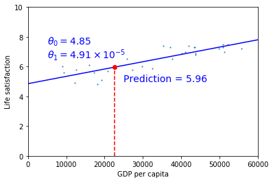

```python
sample_data.plot(kind='scatter', x="GDP per capita", y='Life satisfaction', s=1)

X=np.linspace(0, 60000, 1000)
plt.plot(X, t0 + t1*X, "b")
plt.axis([0, 60000, 0, 10])
plt.text(5000, 7.5, r"$\theta_0 = 4.85$", fontsize=14, color="b")
plt.text(5000, 6.6, r"$\theta_1 = 4.91 \times 10^{-5}$", fontsize=14, color="b")
plt.plot([cyprus_gdp_per_capita, cyprus_gdp_per_capita],
         [0, cyprus_predicted_life_satisfaction], "r--")
plt.text(25000, 5.0, r"Prediction = 5.96", fontsize=14, color="b")
plt.plot(cyprus_gdp_per_capita, cyprus_predicted_life_satisfaction, "ro")
plt.show()
```

# Apresentando uma solução computacional

```python
backup = oecd_bli, gdp_per_capita

def prepare_country_stats(oecd_bli, gdp_per_capita):
    oecd_bli_, gdp_per_capita_ = oecd_bli.copy(), gdp_per_capita.copy()
    oecd_bli_ = oecd_bli_[oecd_bli_["INEQUALITY"]=="TOT"]
    oecd_bli_ = oecd_bli_.pivot(index="Country", columns="Indicator",
                              values="Value")
    gdp_per_capita_.rename(columns={"2015": "GDP per capita"}, inplace=True)
    gdp_per_capita_.set_index("Country", inplace=True)
    full_country_stats_ = pd.merge(left=oecd_bli_, right=gdp_per_capita_,
                                  left_index=True, right_index=True)
    full_country_stats_.sort_values(by="GDP per capita", inplace=True)
    remove_indices = [0, 1, 6, 8, 33, 34, 35]
    countries_to_remove_ = full_country_stats_.index[remove_indices]
    sample_data = full_country_stats_.drop(index=countries_to_remove_, axis=0)
    return sample_data
```

```python
# Exemplo
import matplotlib.pyplot as plt
import numpy as np
import pandas as pd
import sklearn

# Carrega os dados
url = "https://raw.githubusercontent.com/ageron/handson-ml/master/datasets/lifesat/oecd_bli_2015.csv"
oecd_bli=pd.read_csv(url)

url="https://raw.githubusercontent.com/ageron/handson-ml/master/datasets/lifesat/gdp_per_capita.csv"
gdp_per_capita = pd.read_csv(url,thousands=',',delimiter='\t', encoding='latin1', na_values="n/a")
```

```python
# Prepara os dados
country_stats = prepare_country_stats(oecd_bli, gdp_per_capita)
X_train = country_stats[["GDP per capita"]].values
y_train = country_stats["Life satisfaction"].values

# Seleciona o modelo
model = sklearn.linear_model.LinearRegression()

# Treina o modelo
model.fit(X_train, y_train)
```

```
LinearRegression(copy_X=True, fit_intercept=True, n_jobs=1, normalize=False)
```

```
[5.96242338]
```

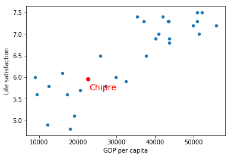

```python
# Realiza uma previsão para o Chipre
X_new = [[22587]]  # PIB per capita do Chipre
print(model.predict(X_new)) # output [[ 5.96242338]]

# Visualiza o resultado
country_stats.plot(kind='scatter', x="GDP per capita", y='Life satisfaction')
plt.plot(X_new, model.predict(X_new), 'ro')
plt.text(23000, 5.7, r"Chipre", fontsize=14, color="r")
plt.show()
```

## Como alterar o modelo?

Vamos acrescentar mais um grau de liberdade ao modelo $$ y = \theta_0 + \theta_1 x + \theta_2 x^2 + \theta_3 x^3 $$

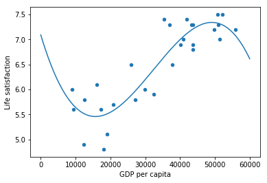

```python
from sklearn import preprocessing
from sklearn import pipeline

poly = preprocessing.PolynomialFeatures(degree=3, include_bias=False)
lin_reg2 = linear_model.LinearRegression()

pipeline_reg = pipeline.Pipeline([('poly', poly),  ('lin', lin_reg2)])
pipeline_reg.fit(X_train, y_train)
X=np.linspace(0, 60000, 1000)
curve = pipeline_reg.predict(X[:, np.newaxis])
country_stats.plot(kind='scatter', x="GDP per capita", y='Life satisfaction')
plt.plot(X, curve)
plt.show()
```

## Como melhorar o modelo?

- Incluir mais atributos (poluição, atenção a saúde, taxa de emprego)
- Melhor qualidade dos dados (alguns países foram excluídos)
- Ajustar outros modelos

```python
full_country_stats.head(1)
```

| Country | Air pollution | Assault rate | Consultation on rule-making | Dwellings without basic facilities | Educational attainment | Employees working very long hours | Employment rate | Homicide rate | Household net adjusted disposable income | Household net financial wealth | ... | Time devoted to leisure and personal care | Voter turnout | Water quality | Years in education | Subject Descriptor | Units | Scale | Country/Series-specific Notes | GDP per capita | Estimates Start After |
| --- | --- | --- | --- | --- | --- | --- | --- | --- | --- | --- | --- | --- | --- | --- | --- | --- | --- | --- | --- | --- | --- |
| Brazil | 18.0 | 7.9 | 4.0 | 6.7 | 45.0 | 10.41 | 67.0 | 25.5 | 11664.0 | 6844.0 | ... | 14.97 | 79.0 | 72.0 | 16.3 | Gross domestic product per capita, current prices | U.S. dollars | Units | See notes for: Gross domestic product, curren... | 8669.998 | 2014.0 |

1 rows × 30 columns

## Sumário

1. Você estudou os dados
2. Você selecionou o modelo
3. Você treinou um modelo num conjunto (de treino)
4. Você aplicou o modelo para fazer previsões em novos dados
5. Você aprensentou uma solução
6. Você alterou o modelo corrente

[figure not shown]

# Trabalhando com dados reais

## Onde conseguir dados reais?

- Repositórios populares
  - [UC Irvine Machine Learning Repository](https://archive.ics.uci.edu/ml/index.php)
  - [Kaggle datasets](https://www.kaggle.com/datasets)
  - [Amazon's AWS datasets](https://aws.amazon.com/pt/opendata/public-datasets/)
- Metaportais
  - [Portal Brasileiro de Dados Abertos](http://dados.gov.br/)
  - [Data Portals](http://dataportals.org/)
  - [Open Data Monitor](http://opendatamonitor.eu/)
- Outras fontes que listam portais de dados abertos
  - [Quora.com question](https://www.quora.com/What-are-the-most-viewed-Quora-questions)
  - [Datasets subreddit](https://www.reddit.com/r/datasets/)

# Classificação

# Testes com problemas sintéticos

- Vamos criar um conjunto de dois semi-círculos intercalados
- Avaliar o desempenho de diferentes classificadores

[figure not shown]

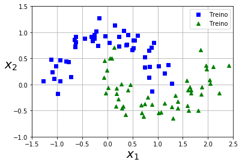

```python
from sklearn.datasets import make_moons
X, y = make_moons(n_samples=100, noise=0.15, random_state=42)

def plot_dataset(X, y, axes, marker=['bs','g^'],label='Treino'):
    plt.plot(X[:, 0][y==0], X[:, 1][y==0], marker[0], label=label)
    plt.plot(X[:, 0][y==1], X[:, 1][y==1], marker[1], label=label)
    plt.axis(axes)
    plt.grid(True, which='both')
    plt.xlabel(r"$x_1$", fontsize=20)
    plt.ylabel(r"$x_2$", fontsize=20, rotation=0)
    plt.legend()

plot_dataset(X, y, [-1.5, 2.5, -1, 1.5]); plt.show()
```

## Separando em conjunto de treinamento e teste

[figure not shown]

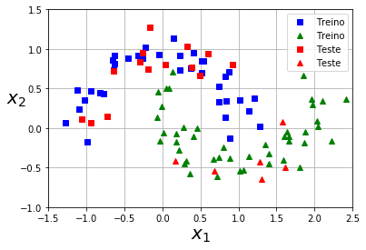

```python
from sklearn.model_selection import train_test_split

X_train, X_test, y_train, y_test = train_test_split(X, y, test_size=0.2,
                                                    random_state=42)

plot_dataset(X_train, y_train, [-1.5, 2.5, -1, 1.5]);
plot_dataset(X_test, y_test, [-1.5, 2.5, -1, 1.5], marker=['rs','r^'], label='Teste');
plt.show()
```

## Criar uma função para visualizar o resultado

```python
import numpy as np
def plot_predictions(clf, axes):
    x0s = np.linspace(axes[0], axes[1], 100)
    x1s = np.linspace(axes[2], axes[3], 100)
    x0, x1 = np.meshgrid(x0s, x1s)
    X_ = np.c_[x0.ravel(), x1.ravel()]
    y_pred = clf.predict(X_).reshape(x0.shape)
    if hasattr(clf,'decision_function'):
        y_decision = clf.decision_function(X_).reshape(x0.shape)
    else:
        y_decision = clf.predict(X_).reshape(x0.shape)

    plt.contourf(x0, x1, y_pred, cmap=plt.cm.brg, alpha=0.2)
    plt.contourf(x0, x1, y_decision, cmap=plt.cm.brg, alpha=0.1)
```

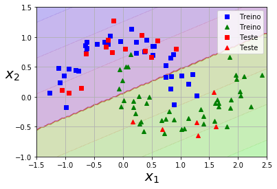

```python
from sklearn.linear_model import SGDClassifier

clf=SGDClassifier(max_iter=10, random_state=42)
clf.fit(X_train, y_train)

plot_predictions(clf, [-1.5, 2.5, -1, 1.5])
plot_dataset(X_train, y_train, [-1.5, 2.5, -1, 1.5])
plot_dataset(X_test, y_test, [-1.5, 2.5, -1, 1.5],marker=['rs','r^'], label='Teste')
```

## Características Polinomiais

```python
from sklearn.preprocessing import PolynomialFeatures
X_poly = PolynomialFeatures(degree=5).fit_transform(X)

print(X.shape, X_poly.shape)
```

```
(100, 2) (100, 21)
```

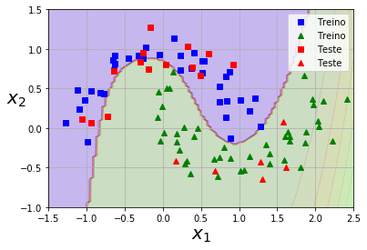

```python
from sklearn.pipeline import Pipeline
from sklearn.preprocessing import PolynomialFeatures

clf = Pipeline([
        ("poly_features", PolynomialFeatures(degree=5)),
        ("sgd_clf", SGDClassifier(max_iter=10, random_state=42))
    ])

clf.fit(X_train, y_train)

plot_predictions(clf, [-1.5, 2.5, -1, 1.5])
plot_dataset(X_train, y_train, [-1.5, 2.5, -1, 1.5])
plot_dataset(X_test, y_test, [-1.5, 2.5, -1, 1.5],marker=['rs','r^'], label='Teste')
```

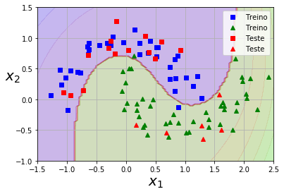

```python
from sklearn.svm import SVC

clf = SVC(kernel="poly", degree=5, coef0=1, C=1)
clf.fit(X_train, y_train)

plot_predictions(clf, [-1.5, 2.5, -1, 1.5])
plot_dataset(X_train, y_train, [-1.5, 2.5, -1, 1.5])
plot_dataset(X_test, y_test, [-1.5, 2.5, -1, 1.5],marker=['rs','r^'], label='Teste')
```

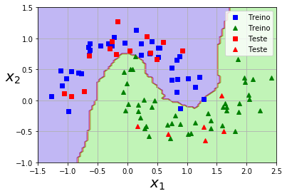

```python
from sklearn.neighbors import KNeighborsClassifier

clf = KNeighborsClassifier(n_neighbors=5)
clf.fit(X_train, y_train)

plot_predictions(clf, [-1.5, 2.5, -1, 1.5])
plot_dataset(X_train, y_train, [-1.5, 2.5, -1, 1.5])
plot_dataset(X_test, y_test, [-1.5, 2.5, -1, 1.5],marker=['rs','r^'], label='Teste')
```

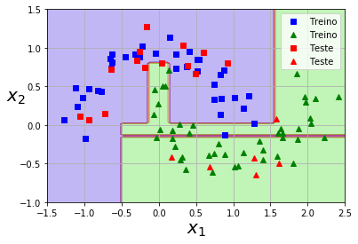

```python
from sklearn.tree import DecisionTreeClassifier

clf = DecisionTreeClassifier()
clf.fit(X_train, y_train)

plot_predictions(clf, [-1.5, 2.5, -1, 1.5])
plot_dataset(X_train, y_train, [-1.5, 2.5, -1, 1.5])
plot_dataset(X_test, y_test, [-1.5, 2.5, -1, 1.5],marker=['rs','r^'], label='Teste')
```

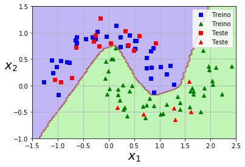

```python
from sklearn.neural_network import MLPClassifier

clf = MLPClassifier(hidden_layer_sizes=(30,20,10),random_state=42, max_iter=2000)
clf.fit(X_train, y_train)

plot_predictions(clf, [-1.5, 2.5, -1, 1.5])
plot_dataset(X_train, y_train, [-1.5, 2.5, -1, 1.5])
plot_dataset(X_test, y_test, [-1.5, 2.5, -1, 1.5],marker=['rs','r^'], label='Teste')
```

## Como avaliar o modelo?

```python
from sklearn.metrics import precision_score, classification_report
clf_list=[
    ('SGD', SGDClassifier(max_iter=10, random_state=42)),
    ('SVC', SVC(kernel="poly", degree=5, coef0=1, C=1)),
    ('KNN', KNeighborsClassifier(n_neighbors=5)),
    ('DT', DecisionTreeClassifier()),
    ('MLP',MLPClassifier(hidden_layer_sizes=(30,20,10),random_state=42, max_iter=2000)),
  ]

X, y = make_moons(n_samples=100, noise=0.15, random_state=42)
X_train, X_test, y_train, y_test = train_test_split(X, y, test_size=0.3,
                                                    random_state=42)

for name, clf in clf_list:
    clf.fit(X_train, y_train)
    print(name, clf.score(X_train, y_train), '\t\t', precision_score(y_test, clf.predict(X_test)))
```

```
SGD 0.8428571428571429 		 0.7692307692307693
SVC 0.9857142857142858 		 0.8333333333333334
KNN 0.9857142857142858 		 0.8333333333333334
DT 1.0 		 0.8333333333333334
MLP 1.0 		 0.7692307692307693
```

```
----------------------------------------
SGD
----------------------------------------
```

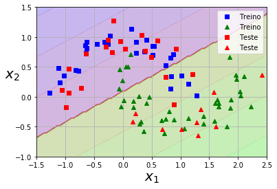

```
----------------------------------------
SVC
----------------------------------------
```

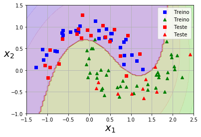

```
----------------------------------------
KNN
----------------------------------------
```

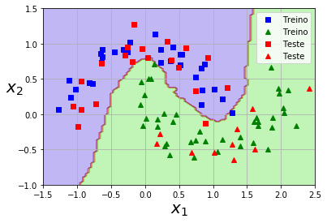

```
----------------------------------------
DT
----------------------------------------
```

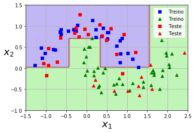

```
----------------------------------------
MLP
----------------------------------------
```

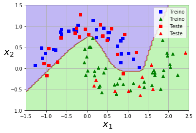

```python
for name, clf in clf_list:
    clf.fit(X_train, y_train)
    print('-'*40+'\n'+name+'\n'+'-'*40)
    plot_predictions(clf, [-1.5, 2.5, -1, 1.5])
    plot_dataset(X_train, y_train, [-1.5, 2.5, -1, 1.5])
    plot_dataset(X_test, y_test, [-1.5, 2.5, -1, 1.5],marker=['rs','r^'], label='Teste')
    plt.show()
```

```python
for name, clf in clf_list:
    clf.fit(X_train, y_train)
    print('-'*40+'\n'+name+'\n'+'-'*40)
    print(classification_report(y_test, clf.predict(X_test)))
```

```
----------------------------------------
SGD
----------------------------------------
             precision    recall  f1-score   support

          0       1.00      0.85      0.92        20
          1       0.77      1.00      0.87        10

avg / total       0.92      0.90      0.90        30

----------------------------------------
SVC
----------------------------------------
             precision    recall  f1-score   support

          0       1.00      0.90      0.95        20
          1       0.83      1.00      0.91        10

avg / total       0.94      0.93      0.93        30

----------------------------------------
KNN
----------------------------------------
             precision    recall  f1-score   support

          0       1.00      0.90      0.95        20
          1       0.83      1.00      0.91        10

avg / total       0.94      0.93      0.93        30

----------------------------------------
DT
----------------------------------------
             precision    recall  f1-score   support

          0       1.00      0.80      0.89        20
          1       0.71      1.00      0.83        10

avg / total       0.90      0.87      0.87        30

----------------------------------------
MLP
----------------------------------------
             precision    recall  f1-score   support

          0       1.00      0.85      0.92        20
          1       0.77      1.00      0.87        10

avg / total       0.92      0.90      0.90        30
```

## O que acontece se mudarmos a semente?

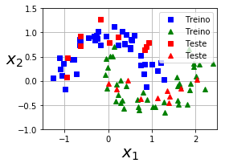

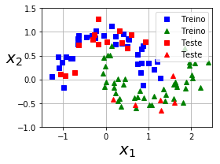

```python
for k,r in enumerate([0,42]):
    X_train, X_test, y_train, y_test = train_test_split(X, y, test_size=0.2,
                                                        random_state=r)
    plt.figure(figsize=(4,3))
    plot_dataset(X_train, y_train, [-1.5, 2.5, -1, 1.5]);
    plot_dataset(X_test, y_test, [-1.5, 2.5, -1, 1.5], marker=['rs','r^'], label='Teste');
    plt.tight_layout()
    plt.show()
```

## KFold é uma aternativa para separar os dados

```python
from sklearn.model_selection import KFold

D=np.array([i for i in 'abcdef'])
print(D)
print()
kf = KFold(n_splits=3)
for k,(train, test) in enumerate(kf.split(D)):
    print("fold %s: %s %s" % (k, D[train], D[test]))
```

```
['a' 'b' 'c' 'd' 'e' 'f']

fold 0: ['c' 'd' 'e' 'f'] ['a' 'b']
fold 1: ['a' 'b' 'e' 'f'] ['c' 'd']
fold 2: ['a' 'b' 'c' 'd'] ['e' 'f']
```

## Vamos retomar com SVM variando o parâmetro *degree*

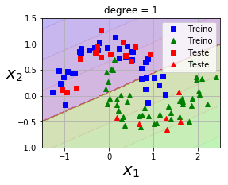

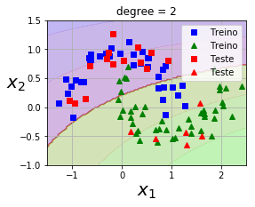

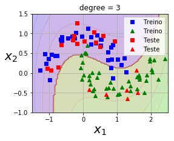

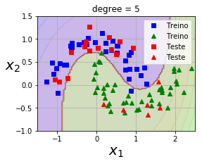

```python
from sklearn.svm import SVC

for degree in [1,2,3,5]:
    clf = SVC(kernel="poly", degree=degree, coef0=1, C=1)
    clf.fit(X_train, y_train)
    plt.figure(figsize=(4,3))
    plot_predictions(clf, [-1.5, 2.5, -1, 1.5])
    plot_dataset(X_train, y_train, [-1.5, 2.5, -1, 1.5])
    plot_dataset(X_test, y_test, [-1.5, 2.5, -1, 1.5],marker=['rs','r^'], label='Teste')
    plt.title("degree = "+str(degree)); plt.show()
```

## SVM variando o parâmetro *C*

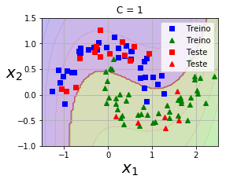

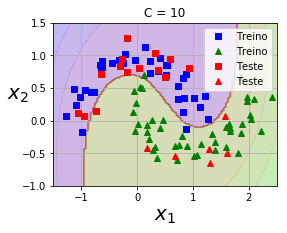

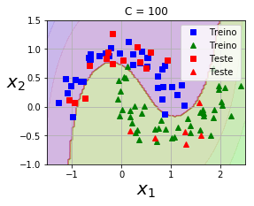

```python
from sklearn.svm import SVC

for C in [1,10,100,]:
    clf = SVC(kernel="poly", degree=3, coef0=1, C=C)
    clf.fit(X_train, y_train)
    plt.figure(figsize=(4,3))
    plot_predictions(clf, [-1.5, 2.5, -1, 1.5])
    plot_dataset(X_train, y_train, [-1.5, 2.5, -1, 1.5])
    plot_dataset(X_test, y_test, [-1.5, 2.5, -1, 1.5],marker=['rs','r^'], label='Teste')
    plt.title("C = "+str(C))
    plt.show()
```

# Como obter os melhores parâmetros?

```python
from sklearn.model_selection import GridSearchCV
parameters = [{'kernel':["poly"], 'coef0':[1,5,100],
                     'degree':[1,2,3,5,10,],
                     'C':[1,10,100,1000,]}]

clf = GridSearchCV(estimator=SVC(), param_grid=parameters, cv=5)
clf.fit(X_train,y_train)
print(clf.best_estimator_)
```

```
SVC(C=1, cache_size=200, class_weight=None, coef0=1,
  decision_function_shape='ovr', degree=5, gamma='auto', kernel='poly',
  max_iter=-1, probability=False, random_state=None, shrinking=True,
  tol=0.001, verbose=False)
```

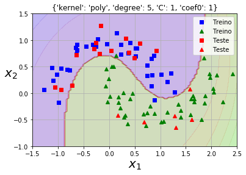

```python
plot_predictions(clf, [-1.5, 2.5, -1, 1.5])
plot_dataset(X_train, y_train, [-1.5, 2.5, -1, 1.5])
plot_dataset(X_test, y_test, [-1.5, 2.5, -1, 1.5],marker=['rs','r^'], label='Teste')
plt.title(clf.best_params_)
plt.show()
```

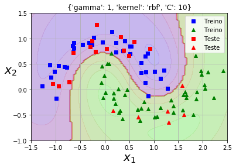

```python
from sklearn.model_selection import GridSearchCV
parameters = [{'kernel':["rbf"], 'gamma':[0.01, 0.1, 1, 2, 5, 10],
                     'C':[1,10,100,1000,]}]

clf = GridSearchCV(estimator=SVC(), param_grid=parameters, cv=5)
clf.fit(X_train,y_train)

plot_predictions(clf, [-1.5, 2.5, -1, 1.5])
plot_dataset(X_train, y_train, [-1.5, 2.5, -1, 1.5])
plot_dataset(X_test, y_test, [-1.5, 2.5, -1, 1.5],marker=['rs','r^'], label='Teste')
plt.title(clf.best_params_)
plt.show()
```

# Redução de Dimensionalidade

- Em alguns casos, os dados disponíveis tem alta dimensionalidade
- Útil para a visualização de dados

[figure not shown]

## A base de dados Iris

- Informações das dimensões da sépala e pétala de flores

[figure not shown]

## Importando os dados

```python
# Setup
from __future__ import division, print_function, unicode_literals
import numpy as np
import matplotlib.pyplot as plt
import pandas as pd
from sklearn import datasets


iris = datasets.load_iris()

print(iris.keys())
print(iris['feature_names'])
print(np.unique(iris['target_names']))
print(np.unique(iris['target']))

X, y, target_names = iris["data"], iris["target"], iris['target_names']
```

```
dict_keys(['target', 'data', 'target_names', 'DESCR', 'feature_names'])
['sepal length (cm)', 'sepal width (cm)', 'petal length (cm)', 'petal width (cm)']
['setosa' 'versicolor' 'virginica']
[0 1 2]
```

```python
pd.DataFrame(data=X, columns=iris['feature_names']).head(12)
```

|  | sepal length (cm) | sepal width (cm) | petal length (cm) | petal width (cm) |
| --- | --- | --- | --- | --- |
| 0 | 5.1 | 3.5 | 1.4 | 0.2 |
| 1 | 4.9 | 3.0 | 1.4 | 0.2 |
| 2 | 4.7 | 3.2 | 1.3 | 0.2 |
| 3 | 4.6 | 3.1 | 1.5 | 0.2 |
| 4 | 5.0 | 3.6 | 1.4 | 0.2 |
| 5 | 5.4 | 3.9 | 1.7 | 0.4 |
| 6 | 4.6 | 3.4 | 1.4 | 0.3 |
| 7 | 5.0 | 3.4 | 1.5 | 0.2 |
| 8 | 4.4 | 2.9 | 1.4 | 0.2 |
| 9 | 4.9 | 3.1 | 1.5 | 0.1 |
| 10 | 5.4 | 3.7 | 1.5 | 0.2 |
| 11 | 4.8 | 3.4 | 1.6 | 0.2 |

```python
import numpy as np
import matplotlib.pyplot as plt
from mpl_toolkits.mplot3d import Axes3D
from sklearn.decomposition import PCA

pca = PCA(n_components = 3)
X3D = pca.fit_transform(X)
pd.DataFrame(data=X3D).head(8)
```

|  | 0 | 1 | 2 |
| --- | --- | --- | --- |
| 0 | -2.684207 | 0.326607 | -0.021512 |
| 1 | -2.715391 | -0.169557 | -0.203521 |
| 2 | -2.889820 | -0.137346 | 0.024709 |
| 3 | -2.746437 | -0.311124 | 0.037672 |
| 4 | -2.728593 | 0.333925 | 0.096230 |
| 5 | -2.279897 | 0.747783 | 0.174326 |
| 6 | -2.820891 | -0.082105 | 0.264251 |
| 7 | -2.626482 | 0.170405 | -0.015802 |

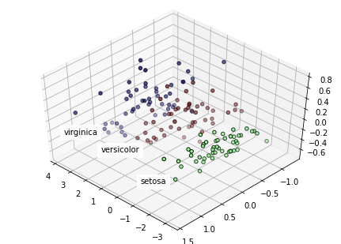

```python
fig = plt.figure()
ax = Axes3D(fig, rect=[0, 0, .95, 1], elev=48, azim=134)
for  label,name in enumerate(target_names):
    ax.text3D(X3D[y == label, 0].mean(),
              X3D[y == label, 1].mean() + 1.5,
              X3D[y == label, 2].mean(), name,
              horizontalalignment='center',
              bbox=dict(alpha=.9, edgecolor='w', facecolor='w'))
y_ = np.choose(y, [1, 2, 0]).astype(np.float)
ax.scatter(X3D[:, 0], X3D[:, 1], X3D[:, 2], c=y_, cmap=plt.cm.jet,
           edgecolor='k')
plt.show()
```

```python
pca = PCA(n_components = 2)
X2D = pca.fit_transform(X)
pd.DataFrame(data=X2D).head(8)
```

|  | 0 | 1 |
| --- | --- | --- |
| 0 | -2.684207 | 0.326607 |
| 1 | -2.715391 | -0.169557 |
| 2 | -2.889820 | -0.137346 |
| 3 | -2.746437 | -0.311124 |
| 4 | -2.728593 | 0.333925 |
| 5 | -2.279897 | 0.747783 |
| 6 | -2.820891 | -0.082105 |
| 7 | -2.626482 | 0.170405 |

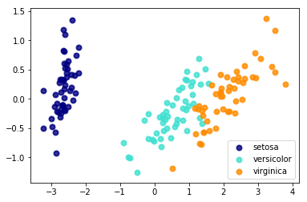

```python
plt.figure()
colors = ['navy', 'turquoise', 'darkorange']
lw = 2
target_names=iris['target_names']
for color, i, target_name in zip(colors, [0, 1, 2], target_names):
    plt.scatter(X2D[y == i, 0], X2D[y == i, 1], color=color,
                alpha=.8, lw=lw,label=target_name)
plt.legend(loc='best', shadow=False, scatterpoints=1)
plt.show()
```